# Fandos Hero Options

Guillermo Fandos

**Option A**Occupancy dynamics — cells of the modelling grid are colonised and go locally extinct, spreading from neighbours. Slow, quiet, gridded.

[interactive chart not shown]

Dept. Biodiversidad, Ecología y Evolución · Universidad Complutense de Madrid

# Guillermo Fandos

Where species are, how they move, and where they will be — asked with data and models.

I am a **quantitative ecologist** working on the processes that shape the distribution and abundance of animal populations. My work combines fieldwork, large-scale data synthesis and statistical modelling to address questions in biogeography, movement ecology and conservation. **Assistant Professor** at the Universidad Complutense de Madrid.

gfandos@ucm.esScholarORCIDGitHub

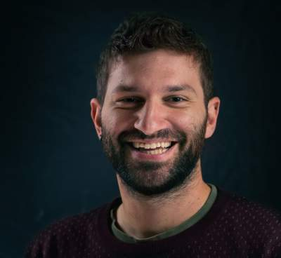

PhD in Ecology, 2017 · Universidad Complutense de Madrid

Fig. 1

**Schematic.** Occupancy dynamics on a modelling grid: cells are colonised from occupied neighbours and go locally extinct at a low rate, so the occupied area drifts and breathes. Simulated, not fitted to data.

**Option B**Drifting suitability — a smooth environmental surface moves slowly under the grid while occurrence records appear where it is high and fade. Organic, softer.

[interactive chart not shown]

Dept. Biodiversidad, Ecología y Evolución · Universidad Complutense de Madrid

# Guillermo Fandos

Where species are, how they move, and where they will be — asked with data and models.

I am a **quantitative ecologist** working on the processes that shape the distribution and abundance of animal populations. My work combines fieldwork, large-scale data synthesis and statistical modelling to address questions in biogeography, movement ecology and conservation. **Assistant Professor** at the Universidad Complutense de Madrid.

gfandos@ucm.esScholarORCIDGitHub

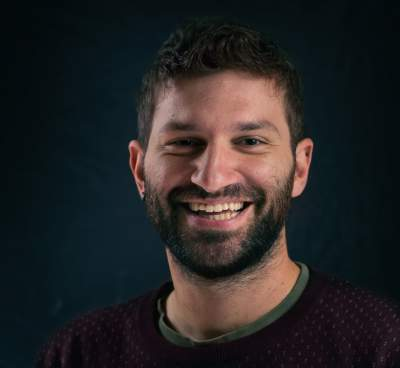

PhD in Ecology, 2017 · Universidad Complutense de Madrid

Fig. 1

**Schematic.** A habitat suitability surface drifting over a modelling grid, with occurrence records appearing where suitability is high. Simulated, not fitted to data.

**Research copy**Reframed as academic themes rather than data sources. The rail now names the sub-disciplines, not the datasets.

Research

## Understanding and forecasting where species live, and how that is changing

**Themes**Movement ecology  
Biogeography

### Movement and the geography of species

Animals move at every scale, from a morning's foraging to a lifetime's dispersal, and those movements set where populations persist, how connected they are and how fast ranges can shift. I study how individual movement scales up to population and range dynamics, and why individuals of the same species differ so much in how far they go.

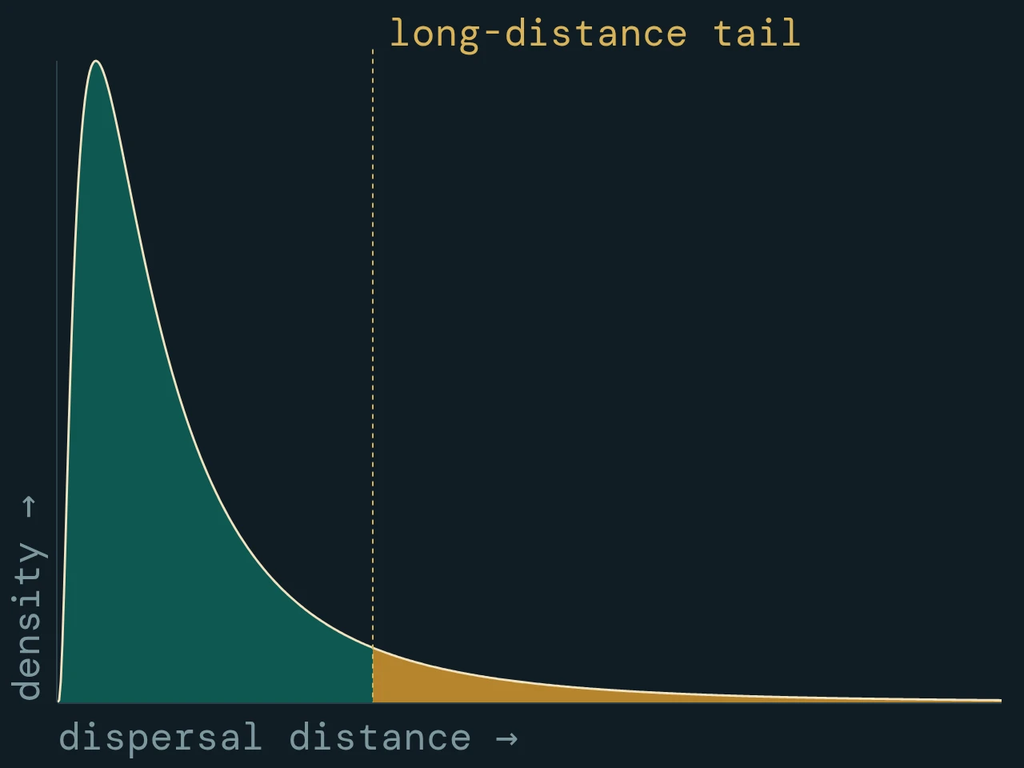

**Schematic.** Dispersal kernel: most individuals settle nearby, a few travel an order of magnitude farther.

**Themes**Statistical ecology  
Species distribution modelling

### Biodiversity modelling and forecasting

Most models of species distributions describe where a species is found, not the processes that put it there. I develop models that carry ecological process explicitly — dispersal, population dynamics, species interactions, imperfect detection — and that integrate heterogeneous data, so that forecasts of biodiversity change rest on mechanism rather than correlation.

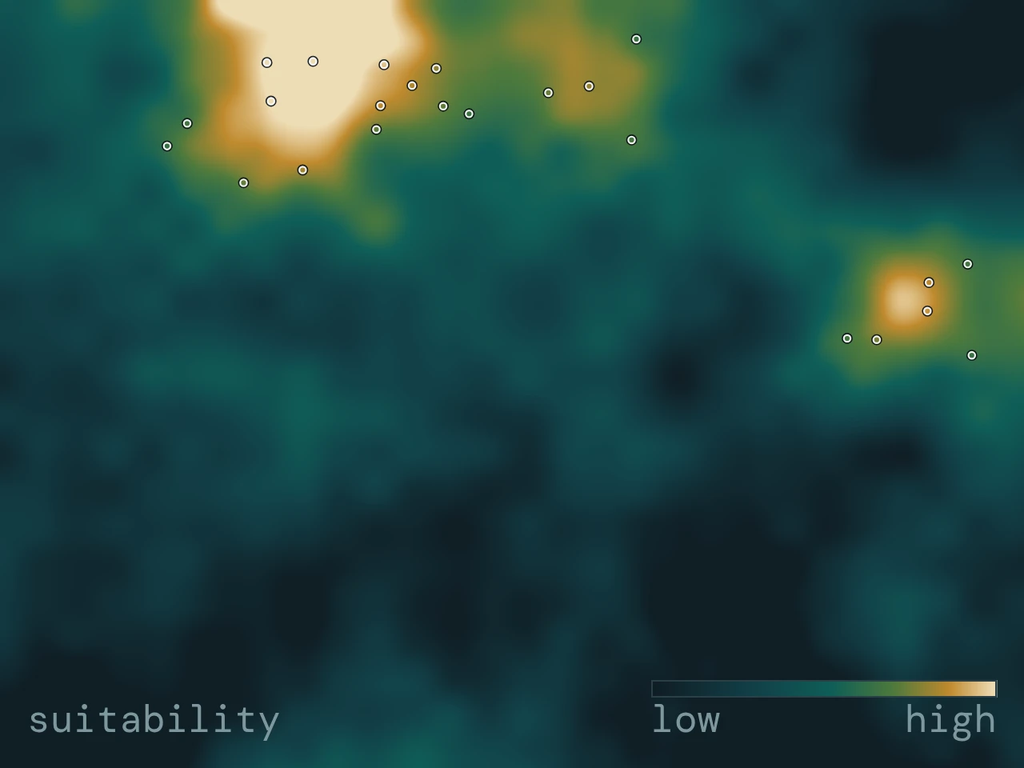

**Schematic.** Habitat suitability surface with occurrence records.

**Themes**Conservation biology  
Global change

### Conservation under global change

Habitat loss and climate change are redrawing species distributions. I work on anticipating which species are most exposed and why, and on turning that understanding into spatial priorities: where and when problems will emerge, and where intervention is most likely to matter.

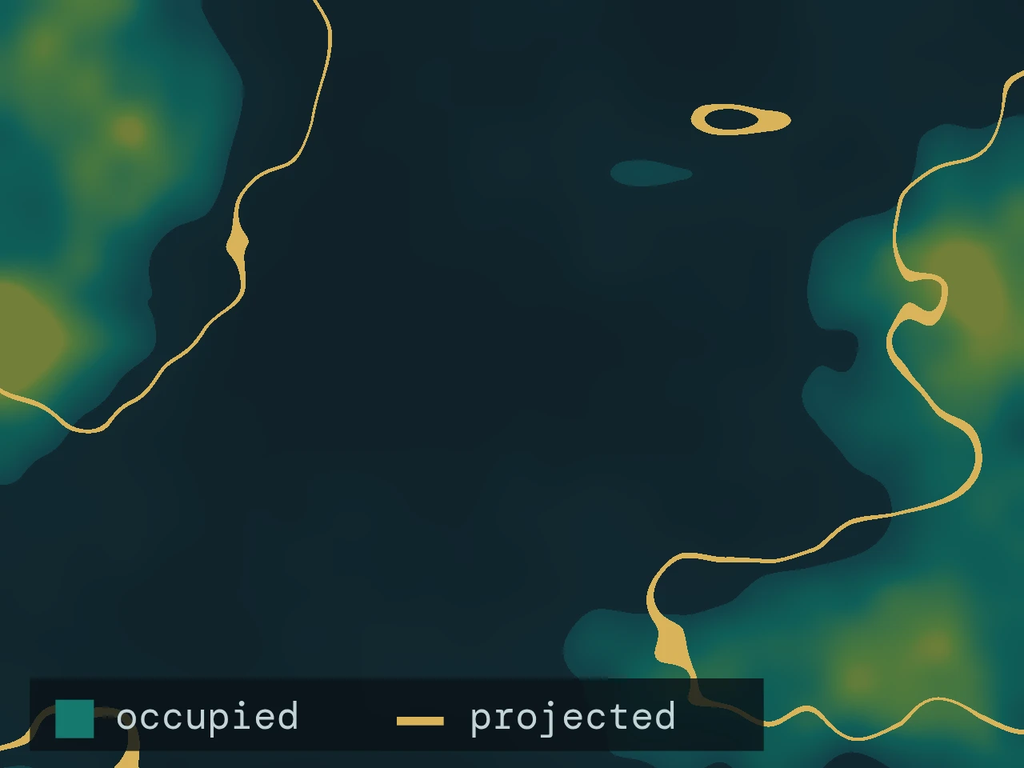

**Schematic.** Occupied area today against a projected contour.

**Themes**Ecological monitoring  
Emerging technologies

### Monitoring biodiversity at scale

Good inference needs good observation. I work on how autonomous sensors, citizen science and long-term surveys can be designed and combined to monitor wildlife at the scales that conservation decisions require, and on the analytical pipelines that turn raw observations into evidence.

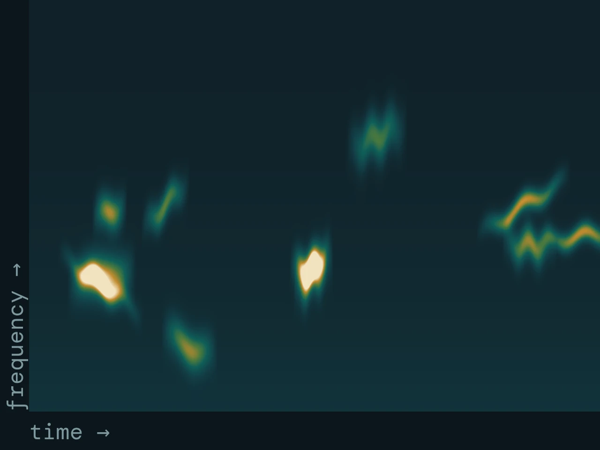

**Schematic.** Spectrogram of a dawn chorus from an autonomous recorder.

Preview. Both heroes animate; with prefers-reduced-motion they show a static frame.